# Lipidomics report

### SM 20:2

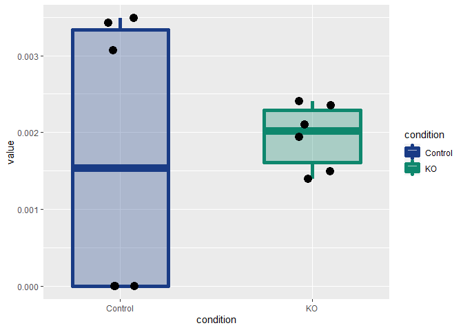

#### Test performed: none

#### p-value (uncorrected)

NA

The data did not meet the criteria for performing a statistical test. There may have been too few non-zero values or the variance of a condition may have been too high.

### SM 22:0

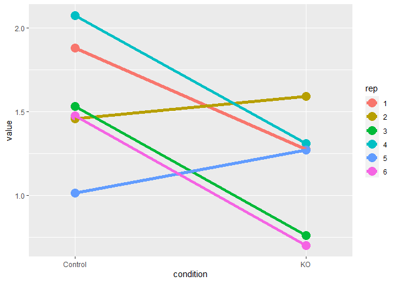

#### Test performed: linear_paired_t_test

#### p-value (uncorrected)

0.0861

Paired t-test performed on linear data. The ratio of standard deviations between the conditions was small enough that the data did not need to be log transformed. The samples were paired.

### SM 22:1

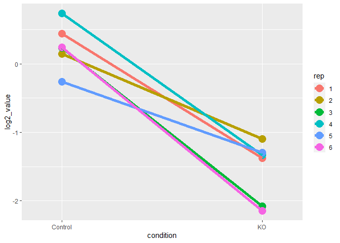

#### Test performed: log2_paired_t_test

#### p-value (uncorrected)

0.000513

Paired t-test performed on log2 transformed data. The ratio of standard deviations between the conditions exceeded a threshold and so the data was log2 transformed. The samples were paired.

### SM 22:2

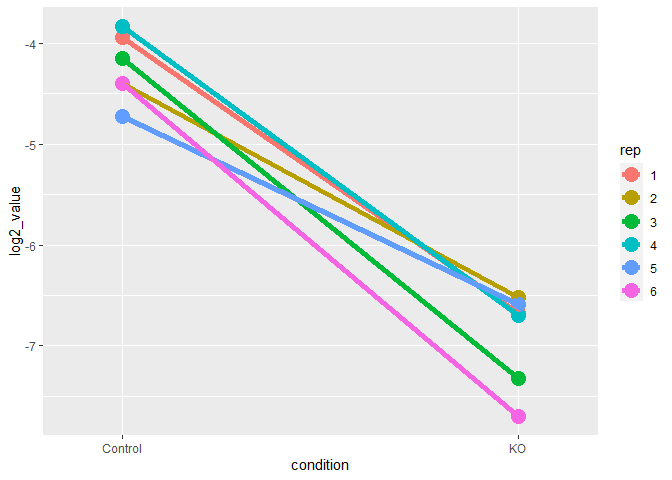

#### Test performed: log2_paired_t_test

#### p-value (uncorrected)

8.9e-05

Paired t-test performed on log2 transformed data. The ratio of standard deviations between the conditions exceeded a threshold and so the data was log2 transformed. The samples were paired.

### SM 24:1

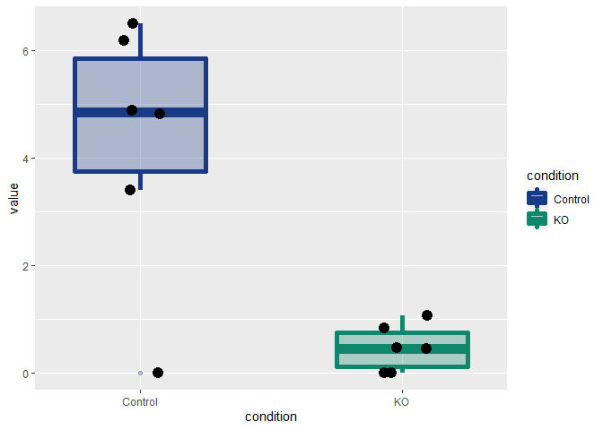

#### Test performed: none

#### p-value (uncorrected)

NA

The data did not meet the criteria for performing a statistical test. There may have been too few non-zero values or the variance of a condition may have been too high.

### SM 24:2

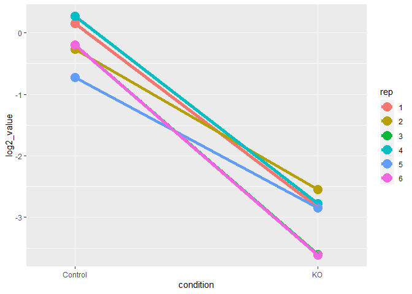

#### Test performed: log2_paired_t_test

#### p-value (uncorrected)

5.41e-05

Paired t-test performed on log2 transformed data. The ratio of standard deviations between the conditions exceeded a threshold and so the data was log2 transformed. The samples were paired.

### SM 24:3

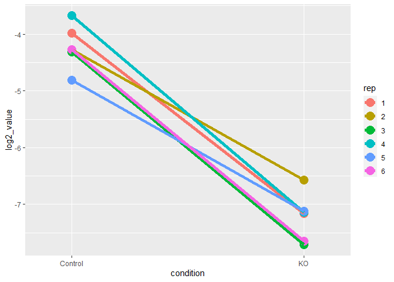

#### Test performed: log2_paired_t_test

#### p-value (uncorrected)

4.28e-05

Paired t-test performed on log2 transformed data. The ratio of standard deviations between the conditions exceeded a threshold and so the data was log2 transformed. The samples were paired.

### SM 24:4

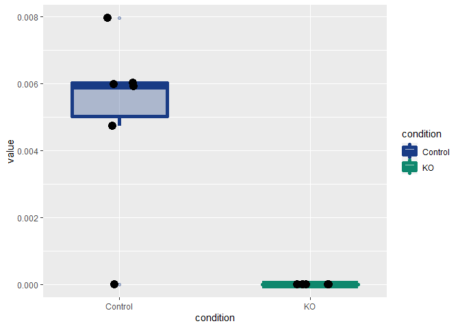

#### Test performed: none

#### p-value (uncorrected)

NA

The data did not meet the criteria for performing a statistical test. There may have been too few non-zero values or the variance of a condition may have been too high.

## Heatmap

### Heatmap ordered by lipid subclass

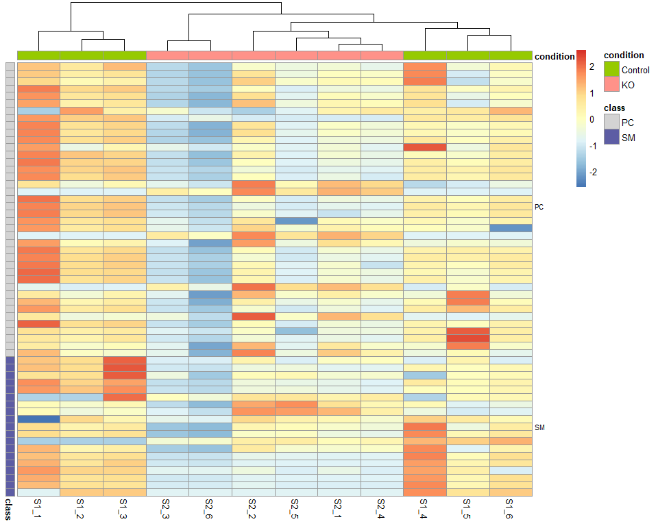

### With row clustering

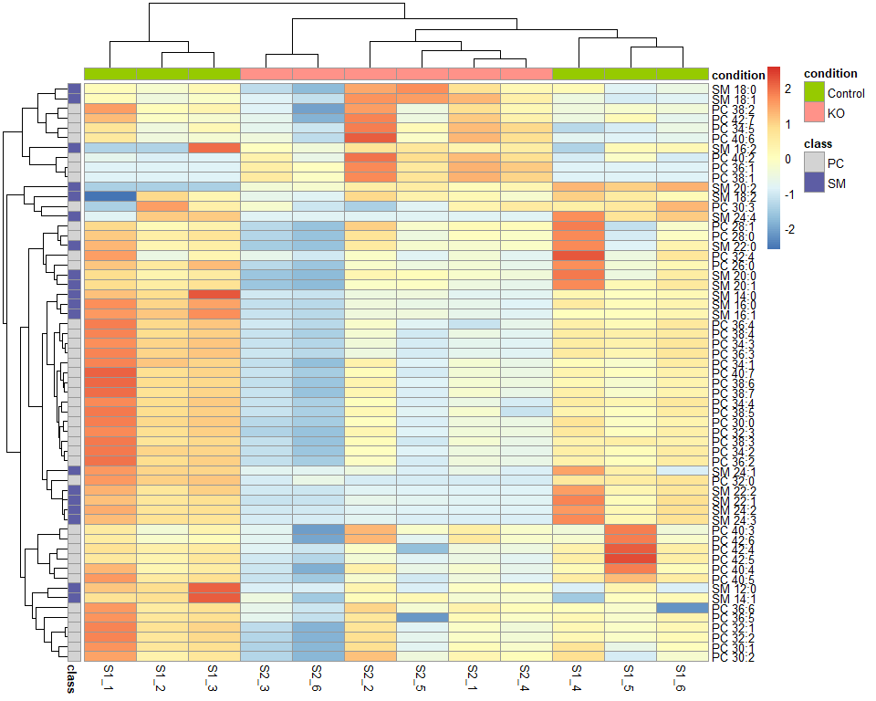

## Test

### PC test plot

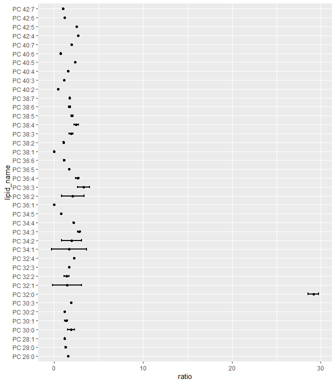

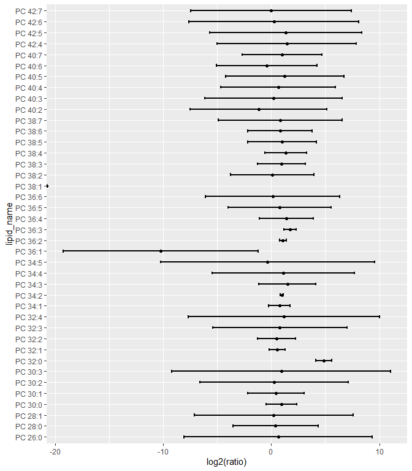

### SM test plot

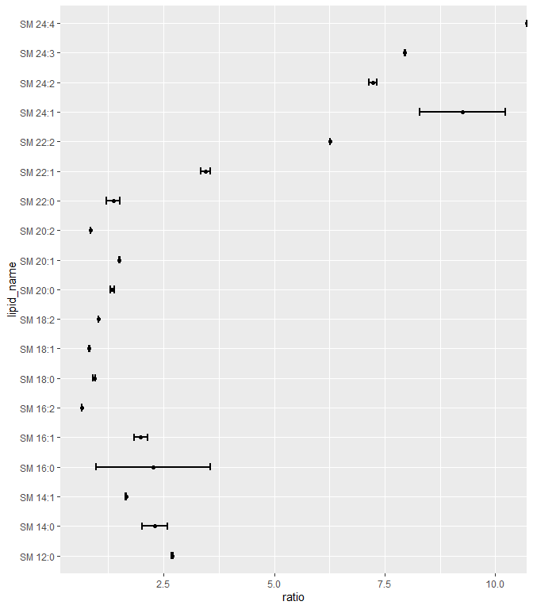

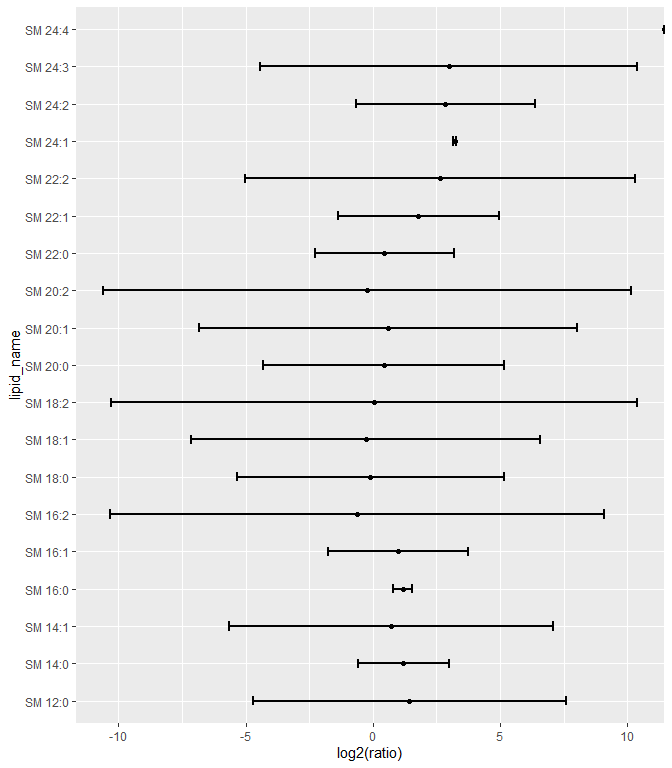